# Operaciones con Series y Dataframes

Una de las características mas importante en torno a los índices de las estructuras de datos en Pandas es el alineamiento. Pandas es capaz de alinear dos estructuras (series o dataframes) en base a las etiquetas de sus índices. Esta propiedad es especialmente interesante cuando se realizan operaciones aritméticas, teniendo en cuenta que dichas operaciones pueden involucar estructuras con etiquetas comunes en sus índices, índices no ordenados, incluso puede darse el caso de tener etiquetas en solo uno de los índices.

En esta Sección mostramos algunos ejemplos de operaciones. En primer lugar cremos dos dataframes con distintas etiquetas para sus índices.

```python
import numpy as np
import pandas as pd
```

```python
datos_1 = np.array([[ 1000, 3000],
                   [ 5000, 1000],
                   [ 4200, 6000],
                   [ 5000, 5500]])
t1 = pd.DataFrame(datos_1, columns= ('Gastos', 'Ingresos'),
                           index = [2006, 2002, 2005, 2007])
t1
```

|  | Gastos | Ingresos |
| --- | --- | --- |
| 2006 | 1000 | 3000 |
| 2002 | 5000 | 1000 |
| 2005 | 4200 | 6000 |
| 2007 | 5000 | 5500 |

```python
datos_2 = np.array([[ 1000, 5000],
       [ 5000, 5000],
       [ 2500, 3000],
       [ 2500, 1500]])
t2 = pd.DataFrame(datos_2, columns= ( 'Gastos', 'Ingresos'),
                           index = [2002,2006, 2007, 2008])
```

## Ordenación de índices y valores

La ordenación de los datos por algún criterio es una operación muy habitual cuando se trata de analizar datos. El método `sort_index` de la clase `DataFrame` ordena lexicográficamente los índices de un dataframes en base a cualquiera de sus índices.

```python
t1
```

|  | Gastos | Ingresos |
| --- | --- | --- |
| 2006 | 1000 | 3000 |
| 2002 | 5000 | 1000 |
| 2005 | 4200 | 6000 |
| 2007 | 5000 | 5500 |

```python
t1.sort_index()
```

|  | Gastos | Ingresos |
| --- | --- | --- |
| 2002 | 5000 | 1000 |
| 2005 | 4200 | 6000 |
| 2006 | 1000 | 3000 |
| 2007 | 5000 | 5500 |

Es posible indicar mediante el argumento `ascending` el tipo de ordenación ascendente o descendente.

```python
t1.sort_index(ascending = False)
```

|  | Gastos | Ingresos |
| --- | --- | --- |
| 2007 | 5000 | 5500 |
| 2006 | 1000 | 3000 |
| 2005 | 4200 | 6000 |
| 2002 | 5000 | 1000 |

```python
t1.sort_index?
```

Para ordenar el índice asociado a las columnas utilizamos el argumento `axis` con valor 1.

```python
t1.sort_index(axis = 1, ascending = False)
```

|  | Ingresos | Gastos |
| --- | --- | --- |
| 2006 | 3000 | 1000 |
| 2002 | 1000 | 5000 |
| 2005 | 6000 | 4200 |
| 2007 | 5500 | 5000 |

Para ordenar los valores de una serie o un dataframe usamos el método `sort_values`. En el caso de los dataframes, es necesario indicar las columnas (mediante una lista) por las que queremos ordenar en el argumento `by`.

```python
t1.sort_values(by = ['Gastos'])
```

|  | Gastos | Ingresos |
| --- | --- | --- |
| 2006 | 1000 | 3000 |
| 2005 | 4200 | 6000 |
| 2002 | 5000 | 1000 |
| 2007 | 5000 | 5500 |

Por defecto, la ordenación es ascendente en todas las columnas, pudiendo indicar otro orden mediante una lista de valores de tipo `bool` en el argumento `ascending`.

```python
t1.sort_values(by = ['Gastos', 'Ingresos'] , ascending = [True, False])
```

|  | Gastos | Ingresos |
| --- | --- | --- |
| 2006 | 1000 | 3000 |
| 2005 | 4200 | 6000 |
| 2007 | 5000 | 5500 |
| 2002 | 5000 | 1000 |

Como resultado obtenemos un nuevo dataframe ordenado de forma ascendente en cuanto a la columna Gastos y descendente en cuanto a la columna Ingresos.

## Tratamiento de valores NaN

Resulta bastante habitual cuando se trabaja con datos, encontrarse con valores vacíos o desconocidos. Ya hemos comentado anteriormente que estos valores se identifican con `NaN`(Not a Number). Aunque Pandas es capaz de tratar este tipo de valores de forma implícita, resulta de mucha utilidad conocer las herramientas que proporciona Pandas para su manejo.

Por un lado, es posible asignar valores `NaN` de forma explícita usando el valor `np.nan` de la librería `NumPy`.

```python
s3 = pd.Series([1, np.nan, 2], index = ['A', 'B', 'C'])
```

```python
s3
```

```
A    1.0
B    NaN
C    2.0
dtype: float64
```

Una de las opciones para eliminar masivamente estos valores, es usar el método `dropna`. El resultado es una nueva estructura de datos sin valores `NaN`.

```python
s3.dropna()
```

```
A    1.0
C    2.0
dtype: float64
```

```python
s3
```

```
A    1.0
B    NaN
C    2.0
dtype: float64
```

En el caso de dataframes, los valores `NaN` pueden estar distribuídos en varias columnas.

```python
t3 = pd.DataFrame( data = [ (np.nan, 'ES', 46449, np.nan),
                            ('Alemania', np.nan , np.nan, np.nan),
                            ('Japón', 'JP', np.nan, '2005') ],
                       columns =  ['País', 'Código', 'Pob.', 'Año'])
t3
```

|  | País | Código | Pob. | Año |
| --- | --- | --- | --- | --- |
| 0 | NaN | ES | 46449.0 | NaN |
| 1 | Alemania | NaN | NaN | NaN |
| 2 | Japón | JP | NaN | 2005 |

```python
t3.dropna(axis = 1)
```

| 0 |
| --- |
| 1 |
| 2 |

Para eliminar aquellas filas en las que los valores de todas las columnas son `NaN`, usamos las opciones `axis` y `how` con valores `0` y `all` respectivamente.

```python
t3.dropna(how = 'all', axis = 0 )
```

|  | País | Código | Pob. | Año |
| --- | --- | --- | --- | --- |
| 0 | NaN | ES | 46449.0 | NaN |
| 1 | Alemania | NaN | NaN | NaN |
| 2 | Japón | JP | NaN | 2005 |

```python
t3.dropna( axis = 0,  thresh = 2 )
```

|  | País | Código | Pob. | Año |
| --- | --- | --- | --- | --- |
| 0 | NaN | ES | 46449.0 | NaN |
| 2 | Japón | JP | NaN | 2005 |

En los casos en los no deseamos eliminar datos con valores `NaN`, Pandas ofrece la posibilidad de sustituir dichos valores por un valor por defecto. Para ello usamos el método `fillna` junto con el valor a sustituir.

```python
t3.fillna(0)
```

|  | País | Código | Pob. | Año |
| --- | --- | --- | --- | --- |
| 0 | 0 | ES | 46449.0 | 0 |
| 1 | Alemania | 0 | 0.0 | 0 |
| 2 | Japón | JP | 0.0 | 2005 |

También es posible indicar un valor por defecto distinto para cada columna. En ese caso, usaremos un diccionario como argumento del método `fillna`. Las claves del diccionario serán las etiquetas del índice de las columnas afectadas y el valor asociado a cada una de las claves, será el valor por defecto que sustituye a `NaN`.

```python
d = {'País': 'ZZ', 'Código': '------', 'Pob.': 0}
t3.fillna(d)
```

|  | País | Código | Pob. | Año |
| --- | --- | --- | --- | --- |
| 0 | ZZ | ES | 46449.0 | NaN |
| 1 | Alemania | ------ | 0.0 | NaN |
| 2 | Japón | JP | 0.0 | 2005 |

En las operaciones estadísticas, Pandas ignora los valores `NaN`, pero si no queremos ignorarlos ha de usarse el argumento `skipna`.

```python
t4 = pd.DataFrame( data = [ ( 8, 7, 6),
                                (19, np.nan, 221),
                                (1,1,np.nan) ],
                       columns =  [ '2004', '2005', '2006'],
                       index = [ 'EE', 'IE', 'EL'])
t4
```

|  | 2004 | 2005 | 2006 |
| --- | --- | --- | --- |
| EE | 8 | 7.0 | 6.0 |
| IE | 19 | NaN | 221.0 |
| EL | 1 | 1.0 | NaN |

También es posible calcular la media. Por defecto se ignoran los valores NaN, pero si no queremos ignorarlos ha de usarse la opción `skipna` con valor `False`.

```python
t4.mean()
```

```
2004      9.333333
2005      4.000000
2006    113.500000
dtype: float64
```

## Relación entre variables: Correlación y covarianza

Entre las operaciones estadísticas más comunes se encuentran la correlación y la covarianza. Estas operaciones se representan en Pandas mediante los métodos `corr` y `cov` respectivamente. Ambos métodos se encuentran definidos tanto en la clase `Series` como en la clase `DataFrame`. Así, es posible calcular la correlación entre cualquier par de variables de un dataframe, obteniéndose lo que se denomina una matriz de correlación.

```python
datos = [[40, 58, 115],[ 42, 59, 116],
       [ 43, 59, 117], [ 41, 61, 118],
       [ 43, 59, 117], [ 42, 60, 120],
       [ 38, 61, 120],
       [ 36, 62, 126],
       [ 40, 63, 122]]
```

```python
t5 = pd.DataFrame(datos, columns = ['Edad', 'Peso', 'Altura'])
t5
```

|  | Edad | Peso | Altura |
| --- | --- | --- | --- |
| 0 | 40 | 58 | 115 |
| 1 | 42 | 59 | 116 |
| 2 | 43 | 59 | 117 |
| 3 | 41 | 61 | 118 |
| 4 | 43 | 59 | 117 |
| 5 | 42 | 60 | 120 |
| 6 | 38 | 61 | 120 |
| 7 | 36 | 62 | 126 |
| 8 | 40 | 63 | 122 |

```python
mcorr = t5.corr()
mcorr
```

|  | Edad | Peso | Altura |
| --- | --- | --- | --- |
| Edad | 1.000000 | -0.586604 | -0.728977 |
| Peso | -0.586604 | 1.000000 | 0.844190 |
| Altura | -0.728977 | 0.844190 | 1.000000 |

La matriz de correlación se puede representar mediante un mapa de calor como se muestra a continuación. Utilizamos la función `heatmap` de la librería Seaborn.

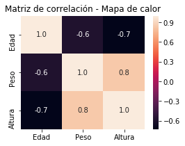

```python
import matplotlib.pyplot as plt
import seaborn as sns
%matplotlib inline

f, ax = plt.subplots(1, figsize=(4, 3))
sns.heatmap(mcorr, vmax=1, square=False, annot=True, fmt='.1f')
ax.set_title('Matriz de correlación - Mapa de calor');
```

De forma análoga, el método `cov` devuelve como resultado un nuevo dataframe que representa la matriz de covarianza.

```python
t5.cov()
```

|  | Edad | Peso | Altura |
| --- | --- | --- | --- |
| Edad | 5.527778 | -2.263889 | -5.875 |
| Peso | -2.263889 | 2.694444 | 4.750 |
| Altura | -5.875000 | 4.750000 | 11.750 |

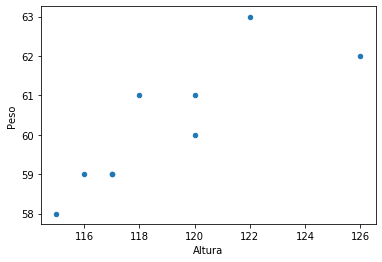

```python
t5.plot(kind='scatter', x='Altura', y='Peso');
plt.xlabel('Altura')
plt.ylabel('Peso');
```

De la misma forma, es posible calcular la correlación entre un par de columnas (correlación entre dos series).

```python
t5['Edad'].corr(t5['Altura'])
```

```
-0.7289767041379851
```